# Evaluación de Sistemas de Vigilancia: Métricas de Rendimiento

Autor/a

IDASH

# 1 Conjunto de datos

Los datos se encuentran almacenados en 3 archivos comprimidos y están disponibles en el repositorio indicado:

- Fallecidos (data/fallecidos.csv.gz)
- Hospitalizados (data/hospitalizados.csv.gz)
- Positivos (data/positivos.csv.gz)

En el mismo repositorio se encuentra el diccionario de datos, en el archivo `diccionario-datos-es.pdf`

Para el tratamiento de datos se usarán las librerías `tidyverse`, `dlookr`, `inspectdf`, `skimr`, `lubridate`, `janitor`, `kableExtra`

## 1.1 Lectura de Datos

```r
fallecidos <- read_csv("data/fallecidos.csv.gz",
  col_types = cols(
    fecha_fallecimiento = col_date(format = "%Y-%m-%d"),
    edad_declarada = col_integer(),
    sexo = col_character(),
    clasificacion_def = col_character(),
    departamento = col_factor(),
    provincia = col_factor(),
    distrito = col_factor(),
    uuid = col_character(),
    age_group = col_factor(),
  )
)
```

```r
hospitalizados <- read_csv("data/hospitalizados.csv.gz",
  col_types = cols(
    eess_nombre = col_factor(),
    id_persona = col_character(),
    edad = col_integer(),
    sexo = col_factor(),
    fecha_ingreso_hosp = col_character(),
    fecha_ingreso_uci = col_character(),
    fecha_ingreso_ucin = col_character(),
    con_oxigeno = col_logical(),
    con_ventilacion = col_logical(),
    fecha_segumiento_hosp_ultimo = col_character(),
    evolucion_hosp_ultimo = col_factor(),
    flag_vacuna = col_factor(),
    fecha_dosis1 = col_character(),
    fabricante_dosis1 = col_factor(),
    fecha_dosis2 = col_character(),
    fabricante_dosis2 = col_factor(),
    fecha_dosis3 = col_character(),
    fabricante_dosis3 = col_factor(),
    cdc_positividad = col_logical(),
    cdc_fecha_fallecido_covid = col_character(),
    cdc_fallecido_covid = col_logical(),
    dep_domicilio = col_factor(),
    prov_domicilio = col_factor(),
    dist_domicilio = col_factor(),
  )
)
```

```r
positivos <- read_csv(
  "data/positivos.csv.gz",
  col_types = cols(
    departamento = col_factor(),
    provincia = col_factor(),
    distrito = col_factor(),
    metododx = col_factor(),
    edad = col_integer(),
    sexo = col_factor(),
    fecha_resultado = col_character(),
    id_persona = col_character()
  ))
```

# 2 Análisis Exploratorio de Datos (EDA) y preparación de datos

El es un proceso que consiste en investigar, visualizar y resumir las principales características y patrones de un conjunto de datos, a menudo utilizando técnicas gráficas y estadísticas descriptivas. Su objetivo principal es entender los datos en profundidad, descubrir anomalías, identificar relaciones entre variables y extraer **insights** iniciales que puedan guiar análisis posteriores más formales o la construcción de modelos.

## 2.1 Fallecidos

```r
diagnose(fallecidos)
```

```
# A tibble: 9 × 6
  variables         types missing_count missing_percent unique_count unique_rate
  <chr>             <chr>         <int>           <dbl>        <int>       <dbl>
1 fecha_fallecimie… Date           9479        10.0              298   0.00314
2 edad_declarada    inte…             0         0                110   0.00116
3 sexo              char…             0         0                  2   0.0000211
4 clasificacion_def char…             0         0                  7   0.0000738
5 departamento      fact…             0         0                 26   0.000274
6 provincia         fact…             5         0.00527           21   0.000222
7 distrito          fact…             5         0.00527           44   0.000464
8 uuid              char…          1382         1.46           93402   0.985
9 age_group         fact…             0         0                  5   0.0000527
```

```r
diagnose_numeric(fallecidos)
```

```
# A tibble: 1 × 10
  variables        min    Q1  mean median    Q3   max  zero minus outlier
  <chr>          <int> <dbl> <dbl>  <dbl> <dbl> <int> <int> <int>   <int>
1 edad_declarada     0    57  66.5     68    77   113    91     0    1526
```

En el conjunto de datos se identificaron 6 variables categóricas las cuales a continuación se muestra la distribución de las categorías de cada variable.

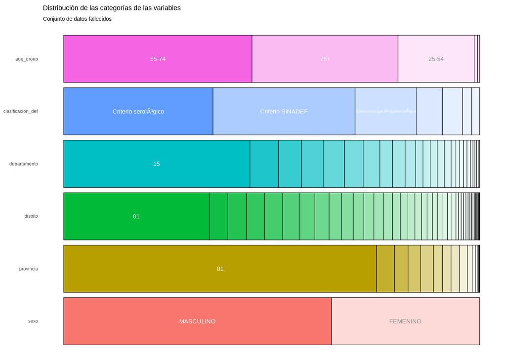

Figura 1: Categorías de la variables tipo factor

```r
var_cat <- inspect_cat(fallecidos[, c(3:7, 9)])
show_plot(var_cat)+
    labs(
    title = "Distribución de las categorías de las variables",
    subtitle = "Conjunto de datos fallecidos",
    x = "Categoría")
```

## 2.2 Hospitalizados

```r
diagnose(hospitalizados)
```

```
# A tibble: 24 × 6
   variables        types missing_count missing_percent unique_count unique_rate
   <chr>            <chr>         <int>           <dbl>        <int>       <dbl>
 1 eess_nombre      fact…          6546        12.0               98   0.00180
 2 id_persona       char…             0         0              54242   0.994
 3 edad             inte…          3580         6.56             104   0.00191
 4 sexo             fact…          2851         5.23               3   0.0000550
 5 fecha_ingreso_h… char…             0         0                295   0.00541
 6 fecha_ingreso_u… char…         50636        92.8              295   0.00541
 7 fecha_ingreso_u… char…         52394        96.0              272   0.00499
 8 con_oxigeno      logi…             6         0.0110             3   0.0000550
 9 con_ventilacion  logi…            15         0.0275             3   0.0000550
10 fecha_segumient… char…             1         0.00183          375   0.00687
# ℹ 14 more rows
```

```r
tbdhosp <- diagnose(hospitalizados)
```

```r
diagnose_numeric(hospitalizados)
```

```
# A tibble: 1 × 10
  variables   min    Q1  mean median    Q3   max  zero minus outlier
  <chr>     <int> <dbl> <dbl>  <dbl> <dbl> <int> <int> <int>   <int>
1 edad          1    35  51.9     54    68   103     0     0       0
```

El número de identificación únicas es 54242 y el número de registros es de 54556, por lo que existen pacientes que se hospitalizaron más de una vez.

Las variables catergóricas del conjunto de datos hospitalizados se muestra en el siguiente gráfico.

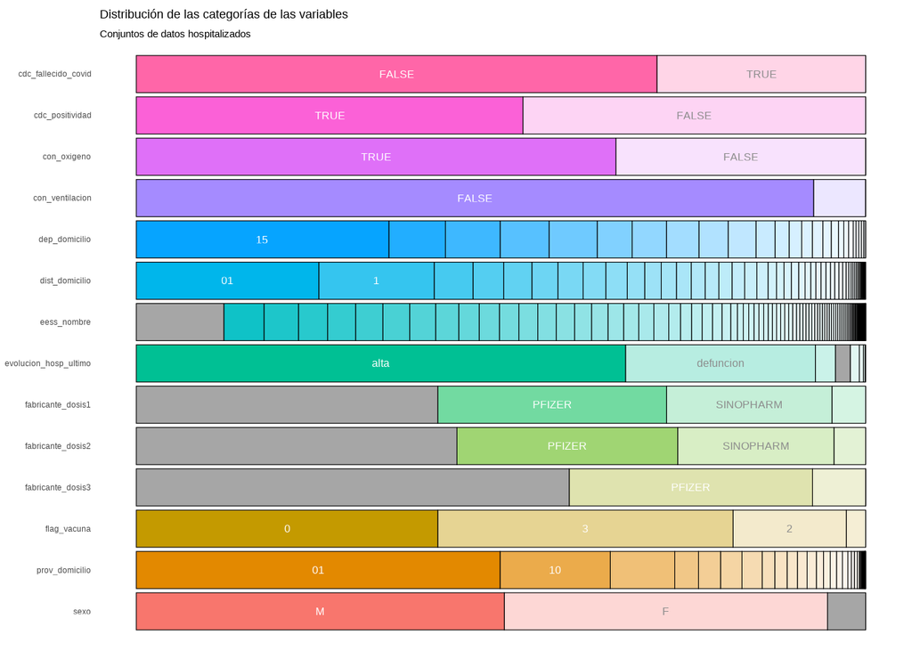

Figura 2: Categorías de la variables tipo factor

```r
var_cat_h <- inspect_cat(hospitalizados[, -c(2,5,6,7,10,15,13,17,20)])
show_plot(var_cat_h) +
    labs(
    title = "Distribución de las categorías de las variables",
    subtitle = "Conjuntos de datos hospitalizados",
    x = "Categoría")
```

### 2.2.1 Preparación y corrección de fechas

Ahora, analizamos la variabilidad de los registros de la variables tipo fechas que existen en el conjunto de datos.

```r
fecha_ingreso_hosp_var <- tabyl(hospitalizados$fecha_ingreso_hosp,
                                show_missing_levels = TRUE)

hospitalizados$fecha_ingreso_hosp <- ymd(hospitalizados$fecha_ingreso_hosp)
```

```r
fecha_ingreso_uci_var <- tabyl(hospitalizados$fecha_ingreso_uci,
                               show_missing_levels = TRUE)

hospitalizados$fecha_ingreso_uci <- ymd(hospitalizados$fecha_ingreso_uci)
```

```r
fecha_ingreso_ucin_var <- tabyl(hospitalizados$fecha_ingreso_ucin,
                                show_missing_levels = TRUE)

hospitalizados$fecha_ingreso_ucin <- ymd(hospitalizados$fecha_ingreso_ucin)
```

```r
fecha_segumiento_hosp_ultimo_var <- tabyl(hospitalizados$fecha_segumiento_hosp_ultimo,
                                          show_missing_levels = TRUE)

hospitalizados$fecha_segumiento_hosp_ultimo <- ymd(hospitalizados$fecha_segumiento_hosp_ultimo)
```

```r
fecha_dosis1_var <- tabyl(hospitalizados$fecha_dosis1,
                          show_missing_levels = TRUE)

#hospitalizados$fecha_dosis1 <- ymd(hospitalizados$fecha_dosis1)
```

Cuando asignamos el formato año-mes-día (`ymd`) se confirma que las observaciones no tienen ese formato y la columna se corrompe Como apreciamos en la revisión, las fechas están en formato día-mes-año.

```r
hospitalizados$fecha_dosis1 <- dmy(hospitalizados$fecha_dosis1)
```

```r
fecha_dosis2_var <- tabyl(hospitalizados$fecha_dosis2,
                          show_missing_levels = TRUE)

hospitalizados$fecha_dosis2 <- ymd(hospitalizados$fecha_dosis2)
```

```r
fecha_dosis3_var <- tabyl(hospitalizados$fecha_dosis3,
                          show_missing_levels = TRUE)

#hospitalizados$fecha_dosis3 <- ymd(hospitalizados$fecha_dosis3)
```

Cuando asignamos el formato año-mes-día (`ymd`) se confirma que las observaciones no tienen ese formato y la columna se corrompe. Como apreciamos en la revisión, las fechas están en formato día-mes-año.

```r
hospitalizados$fecha_dosis3 <- dmy(hospitalizados$fecha_dosis3)
```

```r
fecha_cdc_fallecido_covid_var <- tabyl(hospitalizados$cdc_fecha_fallecido_covid,
                                       show_missing_levels = TRUE)

hospitalizados$cdc_fecha_fallecido_covid <- ymd(hospitalizados$cdc_fecha_fallecido_covid)
```

## 2.3 Positivos

```r
diagnose(positivos)
```

```
# A tibble: 8 × 6
  variables       types   missing_count missing_percent unique_count unique_rate
  <chr>           <chr>           <int>           <dbl>        <int>       <dbl>
1 departamento    factor          52912         5.17              27  0.0000264
2 provincia       factor          48942         4.79              35  0.0000342
3 distrito        factor          48942         4.79              54  0.0000528
4 metododx        factor              0         0                  3  0.00000293
5 edad            integer            55         0.00538          115  0.000112
6 sexo            factor              0         0                  2  0.00000196
7 fecha_resultado charac…             0         0                592  0.000579
8 id_persona      charac…         16980         1.66          989414  0.968
```

```r
diagnose_numeric(positivos)
```

```
# A tibble: 1 × 10
  variables   min    Q1  mean median    Q3   max  zero minus outlier
  <chr>     <int> <dbl> <dbl>  <dbl> <dbl> <int> <int> <int>   <int>
1 edad          0    29  42.0     41    54   120  5920     0    2389
```

El número de identificaciones únicas es de 989414, por lo que existen pacientes que fueron diagnosticados como Covid positivo más de una vez.

Las variables categóricas se muestran en el siguiente gráfico

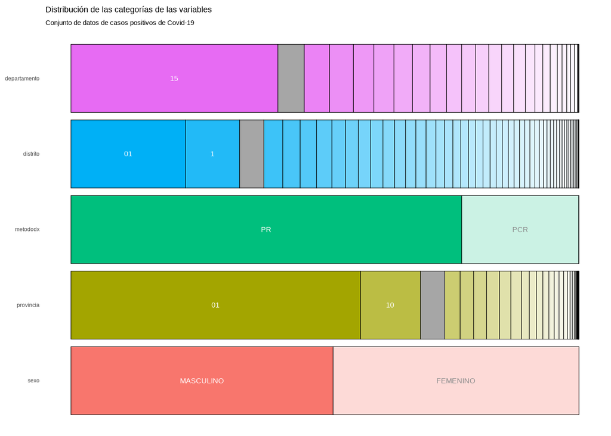

Figura 3: Categorías de la variables tipo factor

```r
var_cat_p <- inspect_cat(positivos[,-c(5,7,8)])
show_plot(var_cat_p)+
    labs(
    title = "Distribución de las categorías de las variables",
    subtitle = "Conjunto de datos de casos positivos de Covid-19",
    x = "Categoría")
```

### 2.3.1 Preparación de datos corrección de fechas

```r
fecha_resultado_var <- tabyl(positivos$fecha_resultado,
                             show_missing_levels = TRUE)

positivos$fecha_resultado_f <- ymd(positivos$fecha_resultado)

num_na_val_fec <- sum(is.na(positivos$fecha_resultado_f))
```

# 3 Calidad de datos

## 3.1 Completitud

### 3.1.1 Fallecidos

La competitud es una característica de la calidad que se refiere al grado en que un conjunto de datos incluye todos los valores o atributos esperados.

En la siguiente tabla se muestra el análisis de completitud de las variables en el conjunto de datos.

```r
na_fallecidos <- inspect_na(fallecidos)
na_fallecidos <- na_fallecidos |>
  mutate(pcnt = round(pcnt, 2)) |>
  filter(pcnt!=0)

kbl(na_fallecidos, col.names = c("Variable", "Valores Perdidos", "Porcentaje(%)")) |>
   kable_styling()
```

Tabla 1: Tabla de completitud del conjunto de datos fallecidos.

| Variable | Valores Perdidos | Porcentaje(%) |
| --- | --- | --- |
| fecha_fallecimiento | 9479 | 10.00 |
| uuid | 1382 | 1.46 |
| provincia | 5 | 0.01 |
| distrito | 5 | 0.01 |

Los mayores porcentajes de pérdida de datos se encuentran en las variables: `fecha_fallecimiento` y `uuid`.

### 3.1.2 Hospitalizaciones

```r
tr_na_hosp <- inspect_na(hospitalizados[,c( "eess_nombre","edad","sexo","evolucion_hosp_ultimo","prov_domicilio")])

tr_na_hosp <- tr_na_hosp |>
  mutate(pcnt = round(pcnt, 2)) |>
  filter(pcnt!=0)

kbl(tr_na_hosp, col.names = c("Variable", "Valores Perdidos", "Porcentaje(%)")) |>
   kable_styling()
```

Tabla 2: Tabla de completitud del conjunto de datos hospitalizados.

| Variable | Valores Perdidos | Porcentaje(%) |
| --- | --- | --- |
| eess_nombre | 6546 | 12.00 |
| edad | 3580 | 6.56 |
| sexo | 2851 | 5.23 |
| evolucion_hosp_ultimo | 1113 | 2.04 |
| prov_domicilio | 45 | 0.08 |

### 3.1.3 Positivos

```r
tr_na_pos <- inspect_na(positivos)

tr_na_pos <- tr_na_pos |>
  mutate(pcnt = round(pcnt, 2)) |>
  filter(pcnt!=0)

kbl(tr_na_pos, col.names = c("Variable", "Valores Perdidos", "Porcentaje(%)")) |>
   kable_styling()
```

Tabla 3: Tabla de completitud del conjunto de datos postivos.

| Variable | Valores Perdidos | Porcentaje(%) |
| --- | --- | --- |
| fecha_resultado_f | 122712 | 12.00 |
| departamento | 52912 | 5.17 |
| provincia | 48942 | 4.79 |
| distrito | 48942 | 4.79 |
| id_persona | 16980 | 1.66 |
| edad | 55 | 0.01 |

## 3.2 Validez

### 3.2.1 Hospitalizados

```r
dosis1_valid <- hospitalizados |>
  group_by(flag_vacuna, fecha_dosis1) |>
  count()

dosis1_valid
```

```
# A tibble: 1,026 × 3
# Groups:   flag_vacuna, fecha_dosis1 [1,026]
   flag_vacuna fecha_dosis1     n
   <fct>       <date>       <int>
 1 3           2021-02-09      21
 2 3           2021-02-10      96
 3 3           2021-02-11     143
 4 3           2021-02-12      69
 5 3           2021-02-13      44
 6 3           2021-02-14       5
 7 3           2021-02-15      37
 8 3           2021-02-16      21
 9 3           2021-02-17      11
10 3           2021-02-18      28
# ℹ 1,016 more rows
```

Como se puede apreciar, no existen fechas asignadas a la variable `fecha_dosis1` incorrectamente, considerando la variable `flag_vacuna` (valores = 0). Por tanto, no aplica el cálculo de la métrica de validez.

```r
dosis2_valid <- hospitalizados |>
  group_by(flag_vacuna, fecha_dosis2) |>
  count()

dosis2_NO_valid <- dosis2_valid |>
  filter(flag_vacuna == "0" & !is.na(fecha_dosis2))

dosis2_NO_valid$flag_vacuna <- as.character(dosis2_NO_valid$flag_vacuna)
```

La métrica de validez de la variable `flag_vacuna` sería 0.02

```r
dosis3_valid <- hospitalizados |>
  group_by(flag_vacuna, fecha_dosis3) |>
  count()

dosis3_valid$flag_vacuna <- as.character(dosis3_valid$flag_vacuna)
```

Todos los registros de la variable `fecha_dosis3` se encuentran consistentes considerando la información de la variable `flag_vacuna`. Por tanto, no aplica el cálculo de la métrica de validez.

### 3.2.2 Positivos

```r
validez_fecha_resultado <- (num_na_val_fec/nrow(positivos)*100)
```

La métrica de validez para la variable `fecha_resultado` en el conjunto de datos `positivos` (casos positivos) corresponde al 12% de fechas con un formato incorrecto que debe ser corregido.

# 4 Conclusiones